# Project 3

异常值多出现在上四分位后，比如fixed.acidity、volatile.acidity、citric.acid、residual.sugar、chlorides、free.sulfur.dioxide、total.sulfur.dioxide、sulphates，发现主要是酒的风味物质差别很大，物性的差值就很小。

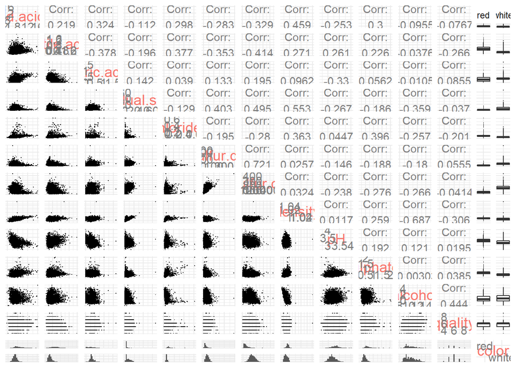

```
##        X        fixed.acidity    volatile.acidity  citric.acid
##  Min.   :   1   Min.   : 3.800   Min.   :0.0800   Min.   :0.0000
##  1st Qu.: 813   1st Qu.: 6.400   1st Qu.:0.2300   1st Qu.:0.2500
##  Median :1650   Median : 7.000   Median :0.2900   Median :0.3100
##  Mean   :2044   Mean   : 7.215   Mean   :0.3397   Mean   :0.3186
##  3rd Qu.:3274   3rd Qu.: 7.700   3rd Qu.:0.4000   3rd Qu.:0.3900
##  Max.   :4898   Max.   :15.900   Max.   :1.5800   Max.   :1.6600
##  residual.sugar     chlorides       free.sulfur.dioxide
##  Min.   : 0.600   Min.   :0.00900   Min.   :  1.00
##  1st Qu.: 1.800   1st Qu.:0.03800   1st Qu.: 17.00
##  Median : 3.000   Median :0.04700   Median : 29.00
##  Mean   : 5.443   Mean   :0.05603   Mean   : 30.53
##  3rd Qu.: 8.100   3rd Qu.:0.06500   3rd Qu.: 41.00
##  Max.   :65.800   Max.   :0.61100   Max.   :289.00
##  total.sulfur.dioxide    density             pH          sulphates
##  Min.   :  6.0        Min.   :0.9871   Min.   :2.720   Min.   :0.2200
##  1st Qu.: 77.0        1st Qu.:0.9923   1st Qu.:3.110   1st Qu.:0.4300
##  Median :118.0        Median :0.9949   Median :3.210   Median :0.5100
##  Mean   :115.7        Mean   :0.9947   Mean   :3.219   Mean   :0.5313
##  3rd Qu.:156.0        3rd Qu.:0.9970   3rd Qu.:3.320   3rd Qu.:0.6000
##  Max.   :440.0        Max.   :1.0390   Max.   :4.010   Max.   :2.0000
##     alcohol         quality         color
##  Min.   : 8.00   Min.   :3.000   Length:6497
##  1st Qu.: 9.50   1st Qu.:5.000   Class :character
##  Median :10.30   Median :6.000   Mode  :character
##  Mean   :10.49   Mean   :5.818
##  3rd Qu.:11.30   3rd Qu.:6.000
##  Max.   :14.90   Max.   :9.000
```

# 单变量绘图选择

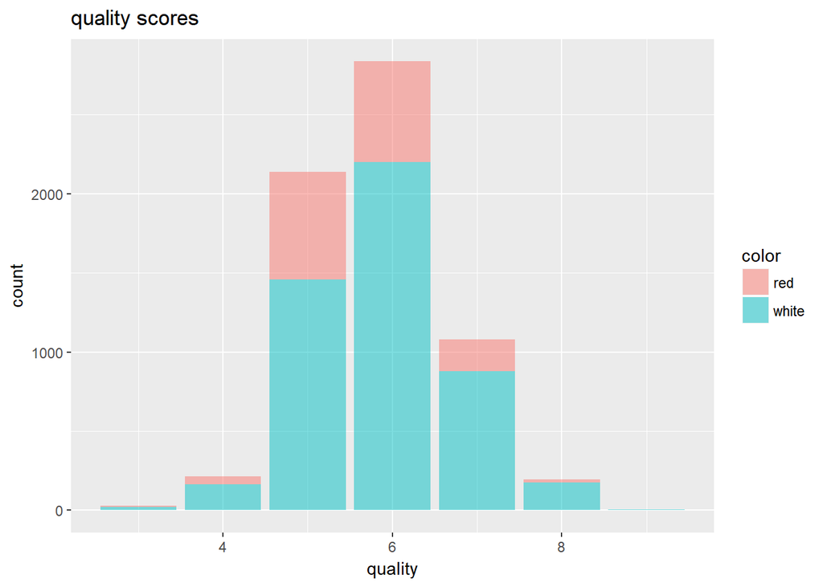

发现上图有点像对数正态分布，我们rescale一下y轴

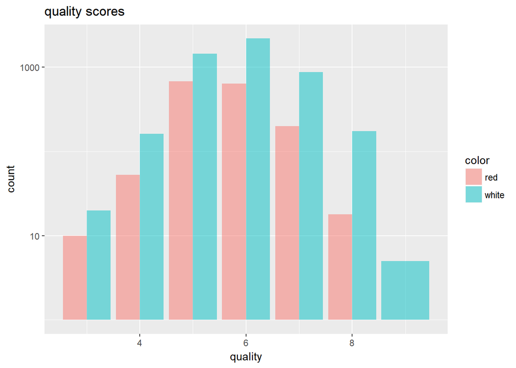

# 单变量分析

### 你的数据集结构是什么？

- 固定酸度（酒石酸 - g / dm^3）
- 挥发性酸度（醋酸 - g / dm^3），在高浓度时会产生令人不愉快的醋味
- 柠檬酸（g / dm^3），量小，给酒的加入新鲜度和风味
- 剩余糖量（g / dm^3）），1g/L含糖量的酒很少见，45g/L含糖量的酒认为是甜的
- 氯化物（氯化钠 g / dm^3）），咸味
- 自由二氧化硫（mg / dm^3），阻止微生物生长和酒氧化
- 总二氧化硫（mg / dm^3），低浓度下，SO2很难检出；自由SO2浓度在高于50 ppm后会闻起来和尝起来很明显
- 密度（g / cm^3），取决于酒精体积比例和糖含量
- pH，大多数位于3-4
- 硫酸盐（硫酸钾 - g / dm^3），添加剂，抗微生物和抗氧化剂。
- 酒精度（体积分数 %）

### 你的数据集内感兴趣的主要特性有哪些？

我感兴趣的主要特性有酒精含量、residual.sugar（甜味）

### 你认为数据集内哪些其他特征可以帮助你探索兴趣特点？

红酒和白酒的区别、风味物质含量（chlorides（咸味）、vol.acid（酸味）、total.sulfur.dioxide（刺激性气味），密度因为主要和酒精度和甜度相关（在上图中也可以看到）

### 根据数据集内已有变量，你是否创建了任何新变量？

# 双变量绘图选择

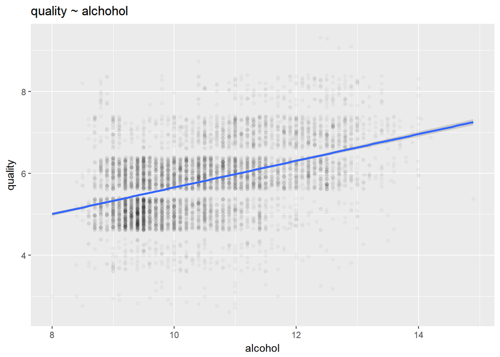

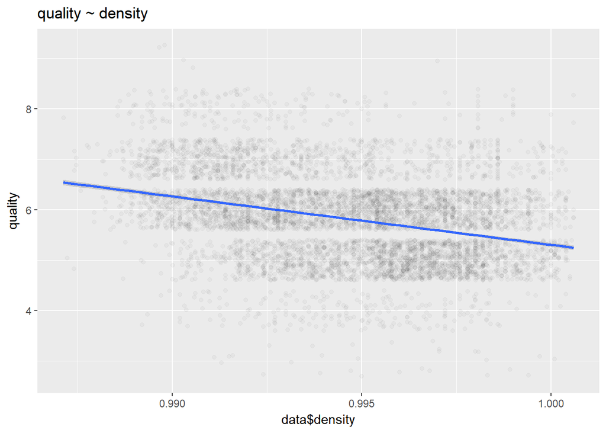

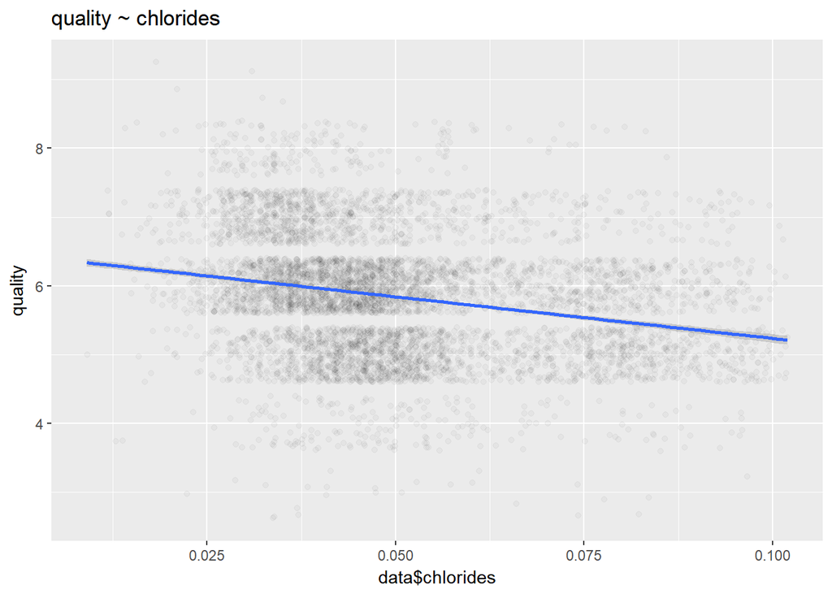

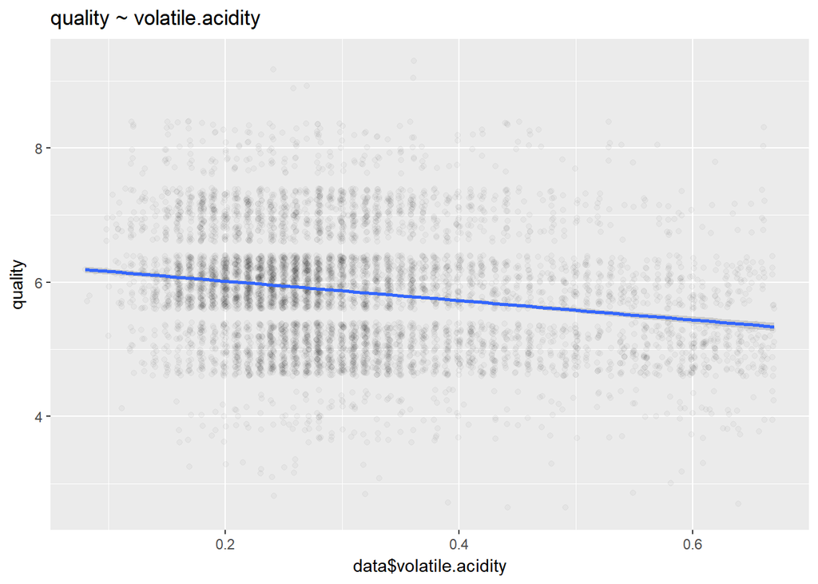

# 双变量分析

### 探讨你在这部分探究中观察到的一些关系。这些感兴趣的特性与数据集内其他特性有什么区别？

质量和酒精度存在一定的正相关性，酒精度越高，评分也可能更高。明显相关性如density、vol.acid，与质量评分呈现负相关。

### 你是否观察到主要特性与其他特性之间的有趣关系？

密度与酒精含量和含糖量存在强的相关性，

### 你发现最强的关系是什么？

# 多变量绘图选择

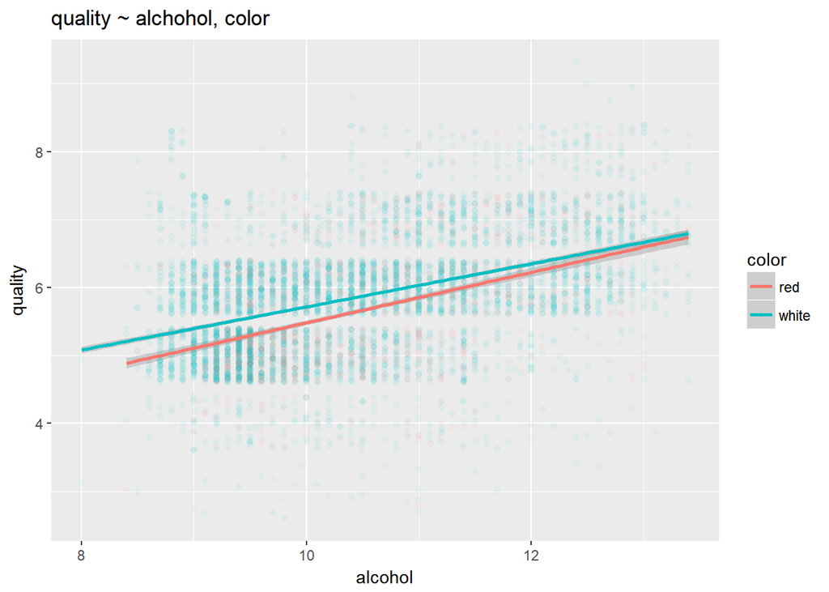

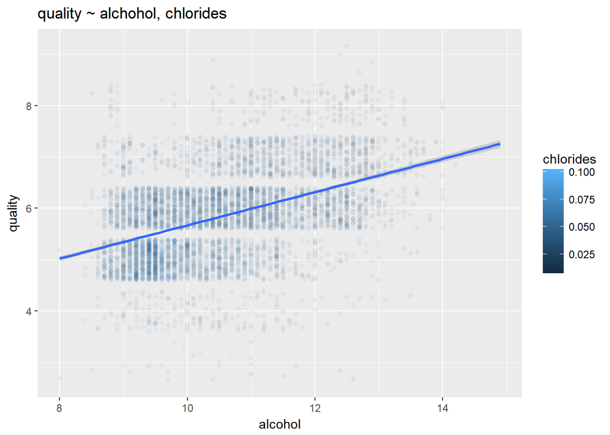

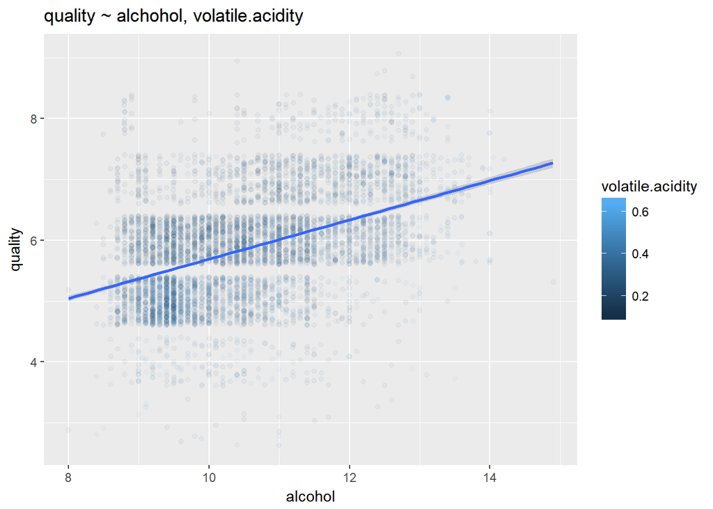

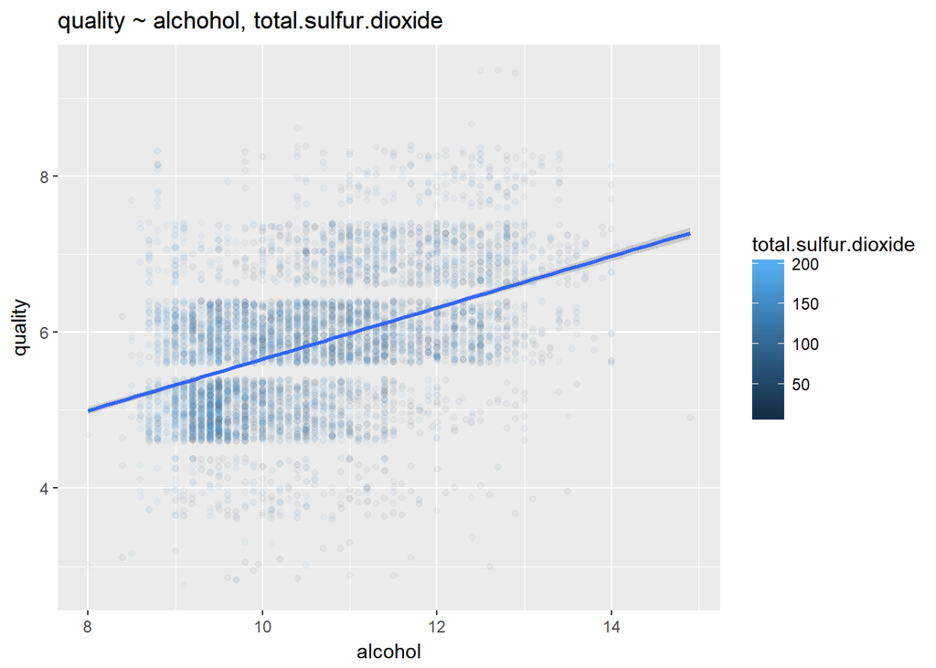

# 多变量分析

### 探讨你在这部分探究中观察到的一些关系。通过观察感兴趣的特性，是否存在相互促进的特性？

红酒和白葡萄酒在质量和酒精含量的关系上表现相似。相同的酒精含量下，白葡萄酒的评分更高。其他的几种风味物质（chlorides、volatile_acidity、total.sulfur.dioxide）的影响不大。 ### 这些特性之间是否存在有趣或惊人的联系呢？

### 选项：你是否创建过数据集的任何模型？讨论你模型的优缺点。

# 定稿图与总结

### 绘图一

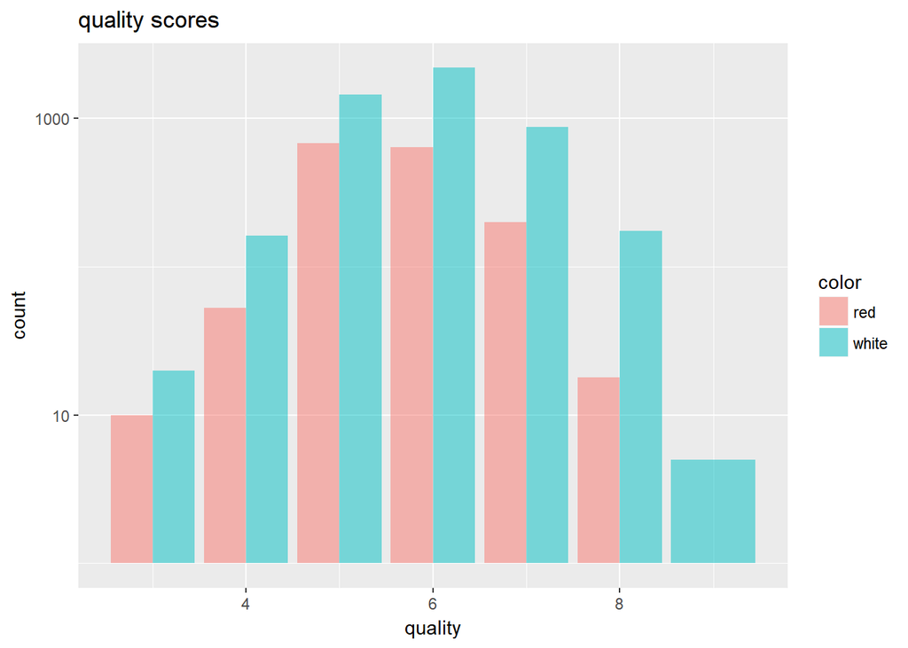

### 绘图二

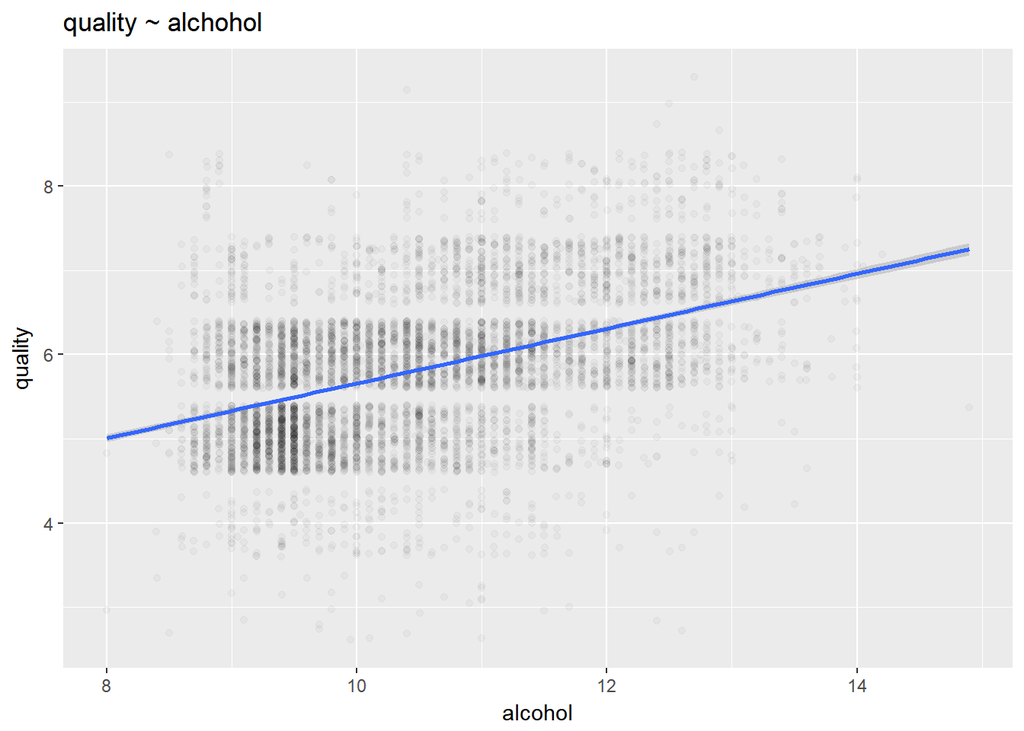

### 绘图三

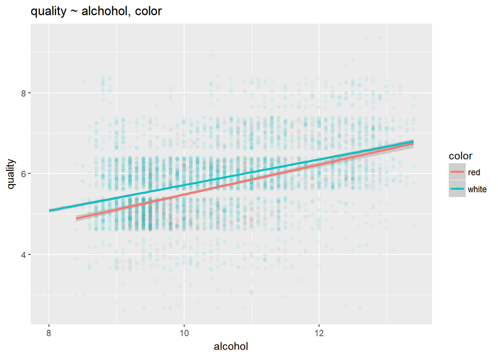

### 描述三

不同的酒的品种（红、白）会对酒精和酒质量的关系产生明显的影响。同样的酒精含量下，白葡萄酒的评分往往更高。 固定酒精含量，相同风味物质可能对应不同的质量评分，方差在不同酒精含量下相近。

# 反思